# Probability

STAT 240 - Fall 2025

Robert Sholl

# Methodologies in Probability

## Observational Studies

> Scientists are concerned that earthquakes are growing in magnitude and that high magnitude earthquakes are causing potentially disasterous tsunamis. They record every earthquake that occurrs worldwide and take note on whether or not it was connected with tsunamis.

## Observational Studies

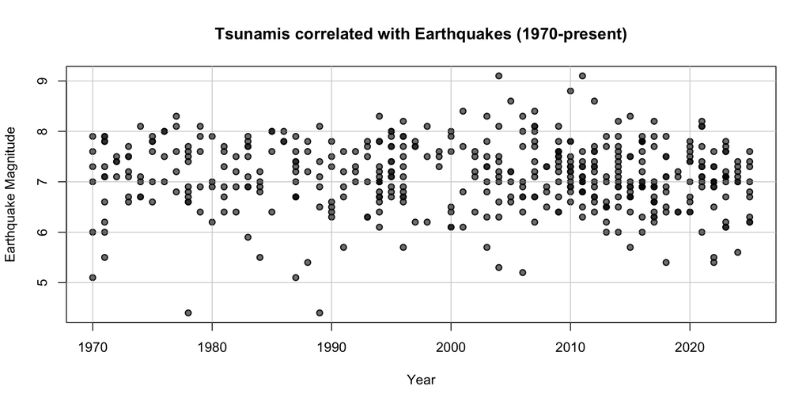

- How can we be certain these earthquakes *caused* the tsunamis they’re connected with?

## Designed Experiments

> The USDA-Agricultural Research Service carried out an experiment on water productivity in response to seasonal timing of irrigation of maize at the Limited Irrigation Research Farm facility in northeastern Colorado starting in 2012. Twelve treatments involved different water availability targeted at specific growth-stages.

## Designed Experiments

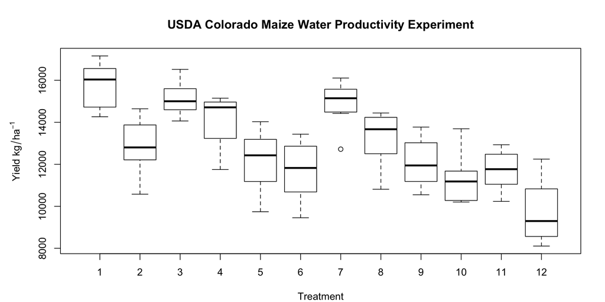

- How can we confirm that the results we observed were the real underlying process rather than random chance?

## Probability

A number between $0$ and $1$ that tells us how *likely* a given “event” is to occur

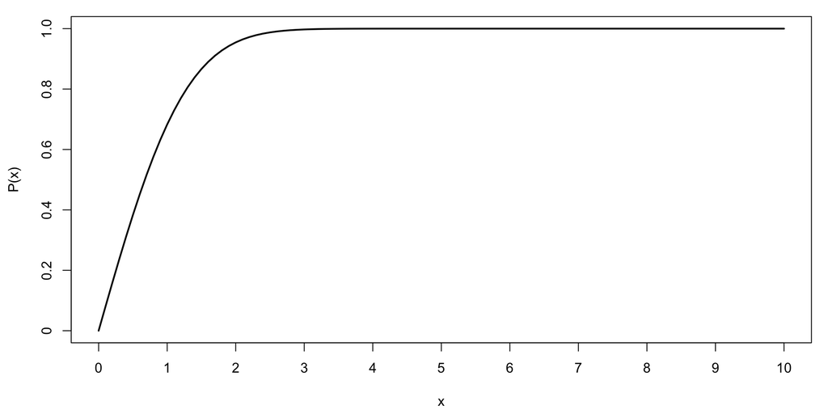

## Probability

$$\begin{array}{|c|c|}
\hline
P(x)=0 & \text{The event cannot occur}\\
\hline
P(x)=0.5 & \text{The event is as likely to occur as it is to not occur}\\
\hline
P(x)=1 & \text{The event must occur}\\
\hline
\end{array}$$

## Terminology

**Experiment** (in context of probability): An activity that results in a definite outcome where the observed outcome is determined by chance.

$$\begin{array}{|c|c|}
\hline
\text{Flip }1 & \text{Flip }2 \\
\hline
\text{Heads} & \text{Heads} \\
\hline
\text{Heads} & \text{Tails} \\
\hline
\text{Tails} & \text{Heads} \\
\hline
\text{Tails} & \text{Tails} \\
\hline
\end{array}$$

## Terminology

**Sample space**: The set of **ALL** possible outcomes of an experiment; denoted by $S$.

$$S=\{\text{HH, HT, TH, TT}\}$$

**Event**: A subset of outcomes belonging to sample space $S$. Typically denoted with capital letters at the beginning of the alphabet ($A$, $B$, $C$, …)

$$A=\{\text{At least one flip is tails}\}=\{\text{TH, HT, TT}\}$$

## Terminology

$$B=\{\text{Both flips are tails}\}=\{\text{TT}\}$$

**Simple event:** An event containing a single outcome in the sample space $S$

**Compound event:** An event formed by combining two or more events (thereby containing two or more outcomes in the sample space $S$).

# Probability Methods

## Subjective Probability

Probability is assigned based on *judgement* or *experience*.

- Expert opinion, best guesses, complete fabrication
- Generally described as “low”, “high”, “very likely”, “very unlikely”
  - Rarely associated with a number
  - How can we attach a number to this?

## Classical Probability

Makes **assumptions** in order to build **mathematical models** from which probabilities can be **derived**.

- Assume that the coin we’ve been flipping is fair
  - What does that assumption imply?

$$P(\text{Tails}) = P(\text{Heads}) = \frac{1}{2}$$

$$P(A) = \frac{\text{number of outcomes in event } A}{\text{total number of outcomes in } S}$$

## Empirical Probability

The probability of an event is the proportion of times that the event occurs.

- Repeat an experiment a large number of times
- Record the outcomes of each experiment

$$P(\text{Event}) = \frac{\text{number of times the event occurs}}{\text{number of replications of the experiment}}$$

## Law of Large Numbers

- As we repeat an experiment *ad infinitum*
  - The outcome proportions *converge* on the truth
- In practice the number of repetitions is much lower than $\infty$
- Let’s flip a coin $1000$ times

## Law of Large Numbers

[figure not shown]

## Law of Large Numbers

[figure not shown]

# Probability Set Theory

## Probability Models

$$\begin{array}{|c|c|c|}
\hline
& \textbf{Ticks} & \textbf{No Ticks}\\
\hline
\textbf{CWD }+ & 42 & 18\\
\hline
\textbf{CWD }- & 78 & 62\\
\hline
\end{array}$$

## Probability Models

**Probability model**: A mathematical function that assigns a probability to each possible event constructed from the simple events in a particular sample space describing a particular experiment.

- What would be the model for our coin flipping experiments?
  - What kind of probability should we base the model in?

$$P(A) = \frac{\text{No. of outcomes in } A}{\text{No. of outcomes in } S} = \frac{k}{n}$$

## Complements

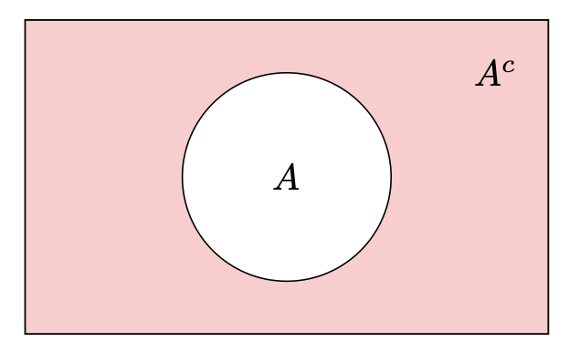

## Unions

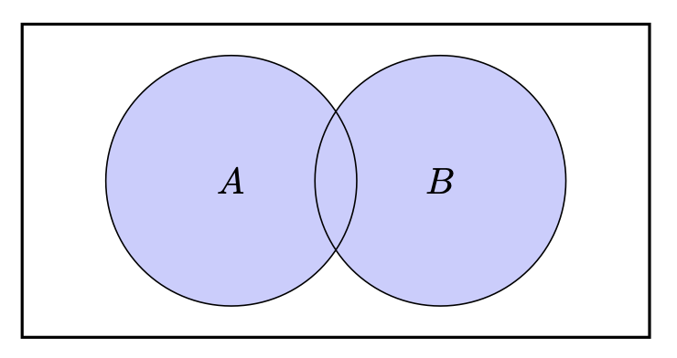

## Intersections

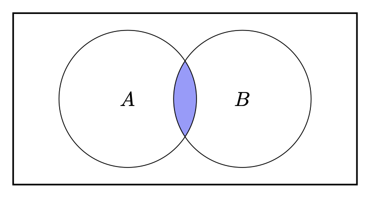

## Mutual Exclusivity

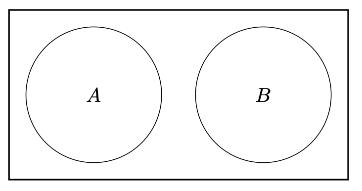

## Contingency Tables

$$\begin{array}{|c|c|c|c|}
\hline
\textbf{Event} & B & B^c & \textbf{Total} \\
\hline
A & A\cap B & A \cap B^c & A \\
\hline
A^c & A^c \cap B & A^c \cap B^c & A^c \\
\hline
\textbf{Total} & B & B^c & S\\
\hline
\end{array}$$

## Conditional Probability

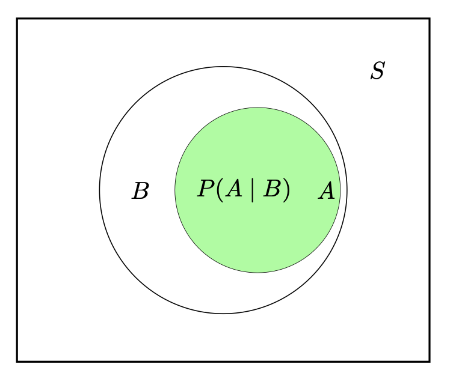